# Graduation project E-commerce

Goal: To analyze the product range, have a look at revenue generated by different goods in stock and make conclusions that would be useful for the marketing team.

##### Link to Tableau dashboard:

https://public.tableau.com/views/YandexGraduationProjectE-Commerce/Dashboard1?:language=en&:display_count=y&publish=yes&:origin=viz_share_link

##### Link to presentation PDF:

https://drive.google.com/file/d/10hg0H8hfEHc3h_kt4SBMFb9d5VWtdylz/view?usp=sharing

Step 1. General Information and preprocessing  
Step 2. Exploratory data analysis

- Unit prices
- Unit quantities
- Retail and individual customers division
- Revenue from retail and individual customers
- Low orders number and multiple orders number between users
- Top 10 items for retail and individual users
- Most common item pairs
- Revenue from our top 50 users
- Daily and monthly revenue
- ARPPU
- Retention
- Cohort analysis
- Top 10 selling products analysis
- Season-dependance analysis
- Names/keywords analysis

Step 3. Hypotheses testing

- Do the retail users generate more revenue?
- Does more orders means more revenue?

Step 4. Overall conclusion

Side resources

## 1. General Information and preprocessing

```python
import pandas as pd
import numpy as np
import re
from scipy import stats as st
import seaborn as sns
import matplotlib.pyplot as plt
import itertools as it
from nltk.stem import SnowballStemmer
import matplotlib as mpl
english_stemmer = SnowballStemmer('english')
#pd.set_option('display.max_rows', 500)


### please change the path to yours!
#data = pd.read_csv('/Users/anastasiapiterskaa/Downloads/ecommerce_dataset_us.csv', sep='\t')

data = pd.read_csv(r'C:\Users\RoG\Desktop\Yandex_Course\Graduation_Project\ecommerce_dataset_us.csv', sep='\t')
data.head()
```

|  | InvoiceNo | StockCode | Description | Quantity | InvoiceDate | UnitPrice | CustomerID |
| --- | --- | --- | --- | --- | --- | --- | --- |
| 0 | 536365 | 85123A | WHITE HANGING HEART T-LIGHT HOLDER | 6 | 11/29/2018 08:26 | 2.55 | 17850.0 |
| 1 | 536365 | 71053 | WHITE METAL LANTERN | 6 | 11/29/2018 08:26 | 3.39 | 17850.0 |
| 2 | 536365 | 84406B | CREAM CUPID HEARTS COAT HANGER | 8 | 11/29/2018 08:26 | 2.75 | 17850.0 |
| 3 | 536365 | 84029G | KNITTED UNION FLAG HOT WATER BOTTLE | 6 | 11/29/2018 08:26 | 3.39 | 17850.0 |
| 4 | 536365 | 84029E | RED WOOLLY HOTTIE WHITE HEART. | 6 | 11/29/2018 08:26 | 3.39 | 17850.0 |

```python
data.info(memory_usage='deep')
```

```
<class 'pandas.core.frame.DataFrame'>
RangeIndex: 541909 entries, 0 to 541908
Data columns (total 7 columns):
 #   Column       Non-Null Count   Dtype
---  ------       --------------   -----
 0   InvoiceNo    541909 non-null  object
 1   StockCode    541909 non-null  object
 2   Description  540455 non-null  object
 3   Quantity     541909 non-null  int64
 4   InvoiceDate  541909 non-null  object
 5   UnitPrice    541909 non-null  float64
 6   CustomerID   406829 non-null  float64
dtypes: float64(2), int64(1), object(4)
memory usage: 157.9 MB
```

#### The data is pretty heavy, we'll need to fix it. Let's change the `StockCode` column to gategory type to save memory.

```python
data['StockCode'] = data['StockCode'].astype('category')
```

```python
data.info(memory_usage='deep')
```

```
<class 'pandas.core.frame.DataFrame'>
RangeIndex: 541909 entries, 0 to 541908
Data columns (total 7 columns):
 #   Column       Non-Null Count   Dtype
---  ------       --------------   -----
 0   InvoiceNo    541909 non-null  object
 1   StockCode    541909 non-null  category
 2   Description  540455 non-null  object
 3   Quantity     541909 non-null  int64
 4   InvoiceDate  541909 non-null  object
 5   UnitPrice    541909 non-null  float64
 6   CustomerID   406829 non-null  float64
dtypes: category(1), float64(2), int64(1), object(3)
memory usage: 127.3 MB
```

```python
data['StockCode'].value_counts().size
```

```
4070
```

#### Change the column names:

```python
data.columns = map(str.lower, data.columns)
data.rename(columns={'invoiceno':'order_id', 'stockcode' : 'item_id',
                     'description' : 'name', 'customerid' : 'uid', 'invoicedate' : 'date'}, inplace=True)
```

#### Let's fill NaN in `name` column by `item_id`, all others drop since we can't know anything about these products and there's not many of them.

```python
data['name'] = data.groupby('item_id')['name'].transform('first') #fill na in 'name'
data.dropna(subset=['name'], inplace=True)
```

```python
data
```

|  | order_id | item_id | name | quantity | date | unitprice | uid |
| --- | --- | --- | --- | --- | --- | --- | --- |
| 0 | 536365 | 85123A | WHITE HANGING HEART T-LIGHT HOLDER | 6 | 11/29/2018 08:26 | 2.55 | 17850.0 |
| 1 | 536365 | 71053 | WHITE METAL LANTERN | 6 | 11/29/2018 08:26 | 3.39 | 17850.0 |
| 2 | 536365 | 84406B | CREAM CUPID HEARTS COAT HANGER | 8 | 11/29/2018 08:26 | 2.75 | 17850.0 |
| 3 | 536365 | 84029G | KNITTED UNION FLAG HOT WATER BOTTLE | 6 | 11/29/2018 08:26 | 3.39 | 17850.0 |
| 4 | 536365 | 84029E | RED WOOLLY HOTTIE WHITE HEART. | 6 | 11/29/2018 08:26 | 3.39 | 17850.0 |
| ... | ... | ... | ... | ... | ... | ... | ... |
| 541904 | 581587 | 22613 | PACK OF 20 SPACEBOY NAPKINS | 12 | 12/07/2019 12:50 | 0.85 | 12680.0 |
| 541905 | 581587 | 22899 | CHILDREN'S APRON DOLLY GIRL | 6 | 12/07/2019 12:50 | 2.10 | 12680.0 |
| 541906 | 581587 | 23254 | CHILDRENS CUTLERY DOLLY GIRL | 4 | 12/07/2019 12:50 | 4.15 | 12680.0 |
| 541907 | 581587 | 23255 | CHILDRENS CUTLERY CIRCUS PARADE | 4 | 12/07/2019 12:50 | 4.15 | 12680.0 |
| 541908 | 581587 | 22138 | BAKING SET 9 PIECE RETROSPOT | 3 | 12/07/2019 12:50 | 4.95 | 12680.0 |

541797 rows × 7 columns

#### Let's check for duplicates:

```python
len(data[data.duplicated()])
```

```
5270
```

```python
data = data.sort_values(by=['order_id', 'item_id'])
data[833:838]
```

|  | order_id | item_id | name | quantity | date | unitprice | uid |
| --- | --- | --- | --- | --- | --- | --- | --- |
| 813 | 536464 | 22945 | CHRISTMAS METAL TAGS ASSORTED | 6 | 11/29/2018 12:23 | 0.85 | 17968.0 |
| 835 | 536464 | 22945 | CHRISTMAS METAL TAGS ASSORTED | 6 | 11/29/2018 12:23 | 0.85 | 17968.0 |
| 812 | 536464 | 22952 | 60 CAKE CASES VINTAGE CHRISTMAS | 2 | 11/29/2018 12:23 | 0.55 | 17968.0 |
| 834 | 536464 | 22956 | 36 FOIL HEART CAKE CASES | 1 | 11/29/2018 12:23 | 2.10 | 17968.0 |
| 856 | 536464 | 22960 | JAM MAKING SET WITH JARS | 1 | 11/29/2018 12:23 | 4.25 | 17968.0 |

#### It looks like there are some duplicates for some products in multiple-item order. Safe to drop them.

```python
data = data.drop_duplicates()
```

#### Changing some data types and making new columns for dates and revenue:

```python
data['date'] = pd.to_datetime(data['date'], format='%m/%d/%Y %H:%M')
data['day'] = data['date'].dt.date
data['revenue'] = data['unitprice'] * data['quantity']
data['week'] = data['date'].dt.week
data['month'] = data['date'].dt.month
data['order_month'] = data['date'].astype('datetime64[M]')
```

```python
data.describe(include='all')
```

|  | order_id | item_id | name | quantity | date | unitprice | uid | day | revenue | week | month | order_month |
| --- | --- | --- | --- | --- | --- | --- | --- | --- | --- | --- | --- | --- |
| count | 536527 | 536527 | 536527 | 536527.000000 | 536527 | 536527.000000 | 401602.000000 | 536527 | 536527.000000 | 536527.000000 | 536527.000000 | 536527 |
| unique | 25788 | 3958 | 3817 | NaN | 23211 | NaN | NaN | 305 | NaN | NaN | NaN | 14 |
| top | 573585 | 85123A | mailout | NaN | 2019-10-29 14:41:00 | NaN | NaN | 2019-12-03 | NaN | NaN | NaN | 2019-11-01 00:00:00 |
| freq | 1114 | 2301 | 3278 | NaN | 1114 | NaN | NaN | 5292 | NaN | NaN | NaN | 84689 |
| first | NaN | NaN | NaN | NaN | 2018-11-29 08:26:00 | NaN | NaN | NaN | NaN | NaN | NaN | 2018-11-01 00:00:00 |
| last | NaN | NaN | NaN | NaN | 2019-12-07 12:50:00 | NaN | NaN | NaN | NaN | NaN | NaN | 2019-12-01 00:00:00 |
| mean | NaN | NaN | NaN | 9.623219 | NaN | 4.633627 | 15281.172576 | NaN | 18.126683 | 30.813754 | 7.482186 | NaN |
| std | NaN | NaN | NaN | 219.152804 | NaN | 97.243424 | 1714.002257 | NaN | 380.695952 | 15.155182 | 3.497798 | NaN |
| min | NaN | NaN | NaN | -80995.000000 | NaN | -11062.060000 | 12346.000000 | NaN | -168469.600000 | 1.000000 | 1.000000 | NaN |
| 25% | NaN | NaN | NaN | 1.000000 | NaN | 1.250000 | 13939.000000 | NaN | 3.750000 | 18.000000 | 5.000000 | NaN |
| 50% | NaN | NaN | NaN | 3.000000 | NaN | 2.080000 | 15145.000000 | NaN | 9.870000 | 34.000000 | 8.000000 | NaN |
| 75% | NaN | NaN | NaN | 10.000000 | NaN | 4.130000 | 16784.000000 | NaN | 17.400000 | 45.000000 | 11.000000 | NaN |
| max | NaN | NaN | NaN | 80995.000000 | NaN | 38970.000000 | 18287.000000 | NaN | 168469.600000 | 51.000000 | 12.000000 | NaN |

#### There's there are some weird outliers in quantity and unitprice that require further investigation.

```python
maxq = data.quantity.max()
minq = data.quantity.min()
data.query('quantity == @maxq or quantity == @minq')
```

|  | order_id | item_id | name | quantity | date | unitprice | uid | day | revenue | week | month | order_month |
| --- | --- | --- | --- | --- | --- | --- | --- | --- | --- | --- | --- | --- |
| 540421 | 581483 | 23843 | PAPER CRAFT , LITTLE BIRDIE | 80995 | 2019-12-07 09:15:00 | 2.08 | 16446.0 | 2019-12-07 | 168469.6 | 49 | 12 | 2019-12-01 |
| 540422 | C581484 | 23843 | PAPER CRAFT , LITTLE BIRDIE | -80995 | 2019-12-07 09:27:00 | 2.08 | 16446.0 | 2019-12-07 | -168469.6 | 49 | 12 | 2019-12-01 |

#### These rows are order and cancelled order. C in `order_id` means cancelled.

```python
print(len(data.query('quantity < 0')))
data.query('quantity < 0').sort_values(by='order_id').head(10)
```

```
10490
```

|  | order_id | item_id | name | quantity | date | unitprice | uid | day | revenue | week | month | order_month |
| --- | --- | --- | --- | --- | --- | --- | --- | --- | --- | --- | --- | --- |
| 2406 | 536589 | 21777 | RECIPE BOX WITH METAL HEART | -10 | 2018-11-29 16:50:00 | 0.0 | NaN | 2018-11-29 | -0.0 | 48 | 11 | 2018-11-01 |
| 4347 | 536764 | 84952C | MIRROR LOVE BIRD T-LIGHT HOLDER | -38 | 2018-11-30 14:42:00 | 0.0 | NaN | 2018-11-30 | -0.0 | 48 | 11 | 2018-11-01 |
| 7188 | 536996 | 22712 | CARD DOLLY GIRL | -20 | 2018-12-01 15:30:00 | 0.0 | NaN | 2018-12-01 | -0.0 | 48 | 12 | 2018-12-01 |
| 7189 | 536997 | 22028 | PENNY FARTHING BIRTHDAY CARD | -20 | 2018-12-01 15:30:00 | 0.0 | NaN | 2018-12-01 | -0.0 | 48 | 12 | 2018-12-01 |
| 7190 | 536998 | 85067 | CREAM SWEETHEART WALL CABINET | -6 | 2018-12-01 15:30:00 | 0.0 | NaN | 2018-12-01 | -0.0 | 48 | 12 | 2018-12-01 |
| 7192 | 537000 | 21414 | SCALLOP SHELL SOAP DISH | -22 | 2018-12-01 15:32:00 | 0.0 | NaN | 2018-12-01 | -0.0 | 48 | 12 | 2018-12-01 |
| 7195 | 537003 | 85126 | LARGE ROUND CUTGLASS CANDLESTICK | -2 | 2018-12-01 15:33:00 | 0.0 | NaN | 2018-12-01 | -0.0 | 48 | 12 | 2018-12-01 |
| 7196 | 537004 | 21814 | HEART T-LIGHT HOLDER | -30 | 2018-12-01 15:34:00 | 0.0 | NaN | 2018-12-01 | -0.0 | 48 | 12 | 2018-12-01 |
| 7197 | 537005 | 21692 | SILVER LATTICE VANILLA CANDLE POT | -70 | 2018-12-01 15:35:00 | 0.0 | NaN | 2018-12-01 | -0.0 | 48 | 12 | 2018-12-01 |
| 7198 | 537006 | 21648 | ASSORTED TUTTI FRUTTI SMALL PURSE | -130 | 2018-12-01 15:36:00 | 0.0 | NaN | 2018-12-01 | -0.0 | 48 | 12 | 2018-12-01 |

#### There are negative quantities that have order_id without C. All of them have 0 unitprices. This might be some re-sended orders (a replace for broken or lost items). It won't affect the product range analysis, safe to drop.

```python
data = data.drop(data.query('quantity < 0').index)
```

#### Let's check for outliers:

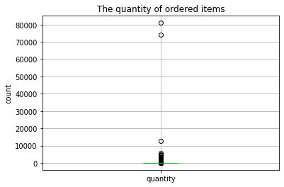

```python
data.boxplot('quantity')
plt.title('The quantity of ordered items')
plt.ylabel('count')
```

```python
data.quantity.quantile(0.95)
```

```
30.0
```

#### There are some extreme outliers. However, 95% of the items quantity in orders is below 30, so let's drop the top 5%.

```python
q_95 = data.quantity.quantile(0.95)
qdrop = data.query('quantity > @q_95')
data.drop(qdrop.index, inplace=True)
```

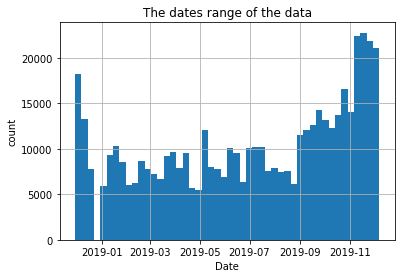

```python
data['day'].hist(bins=48)
plt.title('The dates range of the data')
plt.xlabel('Date')
plt.ylabel('count')
```

```python
data['day'].max()
```

```
datetime.date(2019, 12, 7)
```

#### We don't have a full December 2019. Let's drop the data before Dec 2018 and for the sake of full-year keep dec, 2018.

```python
ts = pd.Timestamp
data.drop(data.query('date < @ts("20181201")').index, inplace=True)
```

#### Let's check the `unitprice`:

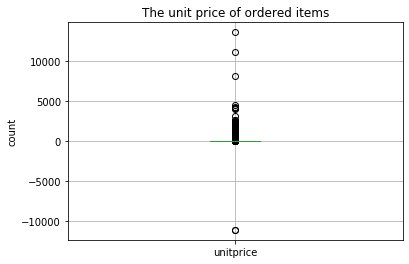

```python
data.boxplot('unitprice')
plt.title('The unit price of ordered items')
plt.ylabel('count')
```

```python
data.query('unitprice < 0')
```

|  | order_id | item_id | name | quantity | date | unitprice | uid | day | revenue | week | month | order_month |
| --- | --- | --- | --- | --- | --- | --- | --- | --- | --- | --- | --- | --- |
| 299983 | A563186 | B | Adjust bad debt | 1 | 2019-08-10 14:51:00 | -11062.06 | NaN | 2019-08-10 | -11062.06 | 32 | 8 | 2019-08-01 |
| 299984 | A563187 | B | Adjust bad debt | 1 | 2019-08-10 14:52:00 | -11062.06 | NaN | 2019-08-10 | -11062.06 | 32 | 8 | 2019-08-01 |

```python
data.query('name == "Adjust bad debt"')
```

|  | order_id | item_id | name | quantity | date | unitprice | uid | day | revenue | week | month | order_month |
| --- | --- | --- | --- | --- | --- | --- | --- | --- | --- | --- | --- | --- |
| 299982 | A563185 | B | Adjust bad debt | 1 | 2019-08-10 14:50:00 | 11062.06 | NaN | 2019-08-10 | 11062.06 | 32 | 8 | 2019-08-01 |
| 299983 | A563186 | B | Adjust bad debt | 1 | 2019-08-10 14:51:00 | -11062.06 | NaN | 2019-08-10 | -11062.06 | 32 | 8 | 2019-08-01 |
| 299984 | A563187 | B | Adjust bad debt | 1 | 2019-08-10 14:52:00 | -11062.06 | NaN | 2019-08-10 | -11062.06 | 32 | 8 | 2019-08-01 |

#### The items with negative price are some sort of refunds. It doesn't have anything to do with product range, so we may delete all of them.

```python
data.drop(data.query('name == "Adjust bad debt"').index, inplace=True)
```

```python
data.unitprice.quantile(0.99)
```

```
18.0
```

#### 99% of the unit prices are below 18, so it's safe to drop the upper 1%.

```python
q_99 = data.unitprice.quantile(0.99)
data.drop(data.query('unitprice > @q_99').index, inplace=True)
```

```python
data.query('unitprice == @data.unitprice.max()')['name'].unique()
```

```
array(['POSTAGE', 'CARRIAGE', 'Manual'], dtype=object)
```

#### Let's drop these rows since it's not a product.

```python
data.drop(data.query('unitprice == @data.unitprice.max()').index, inplace=True)
```

#### Let's check the `names` column:

```python
data.name.value_counts().sort_values(ascending=False).head(20)
```

```
mailout                               3066
WHITE HANGING HEART T-LIGHT HOLDER    1943
JUMBO BAG RED RETROSPOT               1858
REGENCY CAKESTAND 3 TIER              1651
PARTY BUNTING                         1554
LUNCH BAG RED RETROSPOT               1484
SET OF 3 CAKE TINS PANTRY DESIGN      1363
LUNCH BAG SUKI  DESIGN                1261
LUNCH BAG  BLACK SKULL.               1254
ASSORTED COLOUR BIRD ORNAMENT         1212
PACK OF 72 RETROSPOT CAKE CASES       1211
NATURAL SLATE HEART CHALKBOARD        1208
SMALL POPCORN HOLDER                  1131
LUNCH BAG SPACEBOY DESIGN             1131
JUMBO BAG PINK POLKADOT               1127
LUNCH BAG CARS BLUE                   1123
SPOTTY BUNTING                        1120
JUMBO STORAGE BAG SUKI                1118
HEART OF WICKER SMALL                 1107
JUMBO SHOPPER VINTAGE RED PAISLEY     1105
Name: name, dtype: int64
```

#### Let's drop the mailout since it is not a product, but expences.

```python
data.drop(data.query('name == "mailout"').index, inplace=True)
```

#### Let's check the NaN in user id's:

```python
data.query('uid != uid').head()
```

|  | order_id | item_id | name | quantity | date | unitprice | uid | day | revenue | week | month | order_month |
| --- | --- | --- | --- | --- | --- | --- | --- | --- | --- | --- | --- | --- |
| 5370 | 536862 | 15056bl | EDWARDIAN PARASOL BLACK | 1 | 2018-12-01 11:13:00 | 12.72 | NaN | 2018-12-01 | 12.72 | 48 | 12 | 2018-12-01 |
| 5371 | 536862 | 15056p | EDWARDIAN PARASOL PINK | 2 | 2018-12-01 11:13:00 | 12.72 | NaN | 2018-12-01 | 25.44 | 48 | 12 | 2018-12-01 |
| 5372 | 536862 | 20658 | RED RETROSPOT LUGGAGE TAG | 3 | 2018-12-01 11:13:00 | 2.51 | NaN | 2018-12-01 | 7.53 | 48 | 12 | 2018-12-01 |
| 5373 | 536862 | 20725 | LUNCH BAG RED RETROSPOT | 3 | 2018-12-01 11:13:00 | 5.06 | NaN | 2018-12-01 | 15.18 | 48 | 12 | 2018-12-01 |
| 5374 | 536862 | 20941 | FROG CANDLE | 1 | 2018-12-01 11:13:00 | 2.51 | NaN | 2018-12-01 | 2.51 | 48 | 12 | 2018-12-01 |

```python
data.query('uid != uid').tail()
```

|  | order_id | item_id | name | quantity | date | unitprice | uid | day | revenue | week | month | order_month |
| --- | --- | --- | --- | --- | --- | --- | --- | --- | --- | --- | --- | --- |
| 541535 | 581498 | 85049e | SCANDINAVIAN REDS RIBBONS | 4 | 2019-12-07 10:26:00 | 3.29 | NaN | 2019-12-07 | 13.16 | 49 | 12 | 2019-12-01 |
| 541536 | 581498 | 85099B | JUMBO BAG RED RETROSPOT | 5 | 2019-12-07 10:26:00 | 4.13 | NaN | 2019-12-07 | 20.65 | 49 | 12 | 2019-12-01 |
| 541537 | 581498 | 85099C | JUMBO BAG BAROQUE BLACK WHITE | 4 | 2019-12-07 10:26:00 | 4.13 | NaN | 2019-12-07 | 16.52 | 49 | 12 | 2019-12-01 |
| 541538 | 581498 | 85150 | LADIES & GENTLEMEN METAL SIGN | 1 | 2019-12-07 10:26:00 | 4.96 | NaN | 2019-12-07 | 4.96 | 49 | 12 | 2019-12-01 |
| 541539 | 581498 | 85174 | S/4 CACTI CANDLES | 1 | 2019-12-07 10:26:00 | 10.79 | NaN | 2019-12-07 | 10.79 | 49 | 12 | 2019-12-01 |

```python
len(data.query('uid != uid'))
```

```
127263
```

#### There are too many of them and no clear pattern for missing values. But it's not that important for product analysis, so we may keep them.

```python
data['uid'] = data['uid'].fillna(0)
data['uid'] = data['uid'].astype('int')
```

### Conclusion

The data contains more than 500000 rows with information about orders, items and their names, quantiy bought, prices per unit, transaction dates and user ids. The outliers were removed and some missing values were filled. The data represents a full year. The item prices are in range of 0-18. The `user_id` column still contains missing values that were filled with 0.

## 2. EDA

#### Let's investigate the unit prices:

```python
data['unitprice'].describe()
```

```
count    487379.000000
mean          3.185407
std           2.988826
min           0.000000
25%           1.250000
50%           2.100000
75%           4.130000
max          17.880000
Name: unitprice, dtype: float64
```

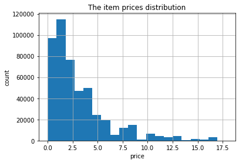

```python
data['unitprice'].hist(bins=20)
plt.title('The item prices distribution')
plt.xlabel('price')
plt.ylabel('count')
```

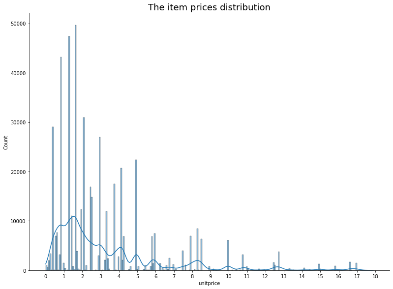

```python
sns.displot(data['unitprice'], kde=True,  height=8, aspect=1.4)
plt.xticks(np.arange(0, max(data['unitprice'])+1, 1.0))
plt.title('The item prices distribution', fontsize=18)
```

```python
data.query('unitprice == @data.unitprice.max()')
```

|  | order_id | item_id | name | quantity | date | unitprice | uid | day | revenue | week | month | order_month |
| --- | --- | --- | --- | --- | --- | --- | --- | --- | --- | --- | --- | --- |
| 302613 | 563439 | 22691 | DOORMAT WELCOME SUNRISE | 1 | 2019-08-14 13:05:00 | 17.88 | 0 | 2019-08-14 | 17.88 | 33 | 8 | 2019-08-01 |
| 410933 | 572185 | 79321 | CHILLI LIGHTS | 2 | 2019-10-19 10:52:00 | 17.88 | 0 | 2019-10-19 | 35.76 | 42 | 10 | 2019-10-01 |
| 428393 | 573426 | 22688 | DOORMAT PEACE ON EARTH BLUE | 1 | 2019-10-29 10:17:00 | 17.88 | 0 | 2019-10-29 | 17.88 | 44 | 10 | 2019-10-01 |
| 439175 | 574356 | 79321 | CHILLI LIGHTS | 1 | 2019-11-02 10:48:00 | 17.88 | 0 | 2019-11-02 | 17.88 | 44 | 11 | 2019-11-01 |
| 479265 | 577150 | 79321 | CHILLI LIGHTS | 1 | 2019-11-16 09:48:00 | 17.88 | 0 | 2019-11-16 | 17.88 | 46 | 11 | 2019-11-01 |
| 513585 | 579557 | 22688 | DOORMAT PEACE ON EARTH BLUE | 1 | 2019-11-28 11:18:00 | 17.88 | 0 | 2019-11-28 | 17.88 | 48 | 11 | 2019-11-01 |

```python
data.unitprice.mode()
```

```
0    1.25
dtype: float64
```

#### Half of the prices are up to 2.10. Maximum price is 17.88 for doormats and lights shaped like chilli pepper. There are some peaks in prices - the most popular price is 1.25.

#### Let's investigate the `quantity` column:

```python
data['quantity'].describe()#hist(bins=11)
```

```
count    487379.000000
mean          5.984616
std           6.421729
min           1.000000
25%           1.000000
50%           3.000000
75%          10.000000
max          30.000000
Name: quantity, dtype: float64
```

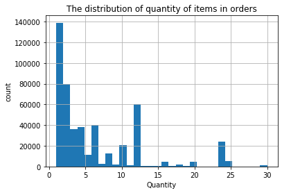

```python
data['quantity'].hist(bins=30)
plt.title('The distribution of quantity of items in orders')
plt.xlabel('Quantity')
plt.ylabel('count')
```

#### Most of the time users order only 1 item, but there are a lot of orders with 2 (possibly for their couple) and 12 (people like dozens) of the same items.

#### Time to investigate what an order consists of:

```python
order_sizes = data.groupby('order_id').size().sort_values().to_frame()
order_sizes.columns = ['order_size']
order_sizes.tail()
```

| order_id | order_size |
| --- | --- |
| 558475 | 674 |
| 580729 | 694 |
| 581492 | 714 |
| 581219 | 732 |
| 573585 | 1078 |

```python
order_sizes.head()
```

| order_id | order_size |
| --- | --- |
| 559658 | 1 |
| 545424 | 1 |
| 545427 | 1 |
| 540507 | 1 |
| 574073 | 1 |

```python
unique=data.groupby('order_id')['item_id'].nunique()
```

```python
data.query('order_id == "568375"')
```

|  | order_id | item_id | name | quantity | date | unitprice | uid | day | revenue | week | month | order_month |
| --- | --- | --- | --- | --- | --- | --- | --- | --- | --- | --- | --- | --- |
| 361740 | 568375 | BANK CHARGES | Bank Charges | 1 | 2019-09-24 17:01:00 | 15.000 | 13405 | 2019-09-24 | 15.000 | 39 | 9 | 2019-09-01 |
| 361741 | 568375 | BANK CHARGES | Bank Charges | 1 | 2019-09-24 17:01:00 | 0.001 | 13405 | 2019-09-24 | 0.001 | 39 | 9 | 2019-09-01 |

```python
merged=order_sizes.merge(unique,on='order_id').reset_index()
merged[merged.order_size!=merged.item_id]
```

|  | order_id | order_size | item_id |
| --- | --- | --- | --- |
| 1922 | 568375 | 2 | 1 |
| 2103 | 558894 | 2 | 1 |
| 2471 | 573325 | 2 | 1 |
| 3030 | 548219 | 3 | 2 |
| 3454 | 557329 | 4 | 3 |
| ... | ... | ... | ... |
| 18868 | 578347 | 598 | 591 |
| 18870 | 538349 | 609 | 596 |
| 18874 | 538071 | 634 | 632 |
| 18880 | 558475 | 674 | 673 |
| 18884 | 573585 | 1078 | 1075 |

1942 rows × 3 columns

```python
order_sizes = data.groupby('order_id')['quantity'].sum().sort_values().to_frame()#.reset_index()
order_sizes.columns = ['order_size']
```

#### There are some massive orders, which indicates retailers among our customers. Let's find them:

```python
order_sizes.describe()
```

|  | order_size |
| --- | --- |
| count | 18885.000000 |
| mean | 154.449351 |
| std | 181.955005 |
| min | 1.000000 |
| 25% | 45.000000 |
| 50% | 106.000000 |
| 75% | 203.000000 |
| max | 4052.000000 |

```python
np.percentile(order_sizes['order_size'], 20)
```

```
33.0
```

#### Let's take the lower 20% of order sizes (33 items per order) as a reasonable limit for individual users. All the orders bigger than that most probably are retail users:

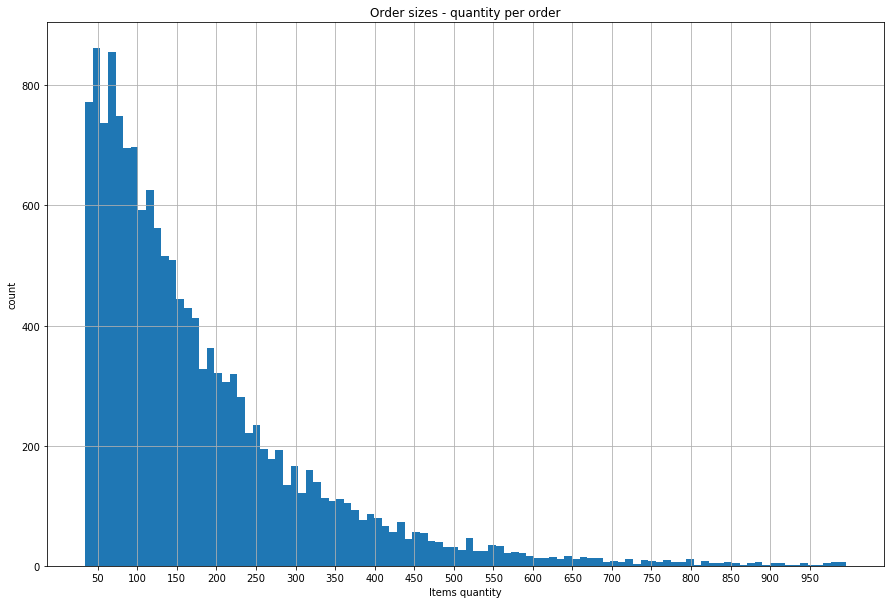

```python
order_sizes[(order_sizes['order_size'] > 33) & (order_sizes['order_size'] < 1000)].hist(bins=100, figsize=(15,10))
#bins = np.linspace(0, 200, 100)
#order_sizes['order_size'].hist(bins=bins, figsize=(15,10))

plt.xticks(np.arange(50, 1000, 50))
plt.title('Order sizes - quantity per order')
plt.xlabel('Items quantity')
plt.ylabel('count')
```

#### The histogram shows the distribution of items per order in retailers' orders. There are ~800 orders with 40-50 items in them.

```python
ret_orders = order_sizes[(order_sizes['order_size'] > 33)].index.to_list()
ret_users = data.query('order_id == @ret_orders and uid != 0').uid.unique().tolist()
ind_users = data.query('uid != @ret_users and uid != 0').uid.unique().tolist()
```

#### Let's compare the revenue from retail and individual customers:

```python
ret_rev = data.query('uid == @ret_users').groupby('order_id')['revenue'].sum().reset_index()
ind_rev = data.query('uid == @ind_users').groupby('order_id')['revenue'].sum().reset_index()
```

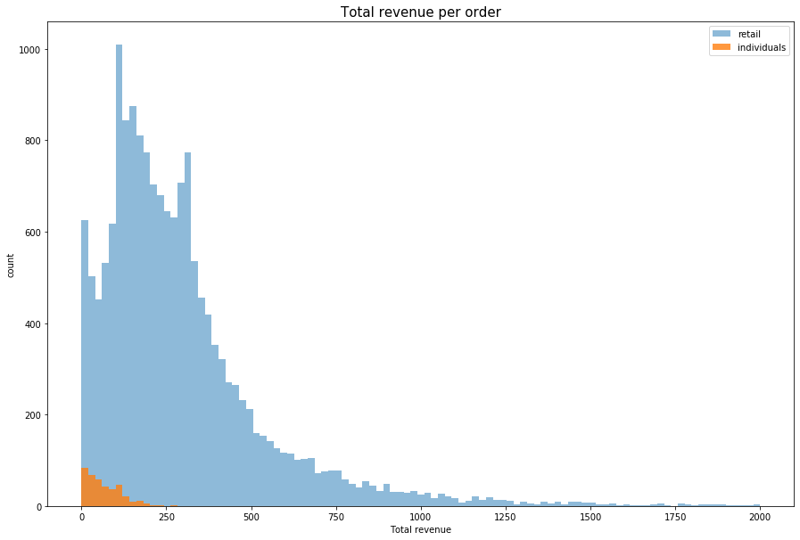

```python
bins = np.linspace(0, 2000, 100)
plt.figure(figsize=(15,10))
plt.hist(ret_rev['revenue'], bins=bins, alpha=0.5, label='retail')
plt.hist(ind_rev['revenue'], bins=bins, alpha=0.8, label='individuals')
plt.legend(loc='upper right')
plt.title('Total revenue per order', fontsize=15)
plt.xlabel('Total revenue')
plt.ylabel('count')
plt.show()
```

#### As we see, individual users generate only a small part of our total revenue. A revenue from them rarely exceeds 100 per order.

#### Let's have a look at how unique the items in retail orders:

```python
order_unique = data.query('order_id == @ret_orders').groupby('order_id').size().to_frame()
order_unique.columns = ['n_unique']
```

```python
order_unique.describe()
```

|  | n_unique |
| --- | --- |
| count | 15085.000000 |
| mean | 31.472125 |
| std | 50.863838 |
| min | 2.000000 |
| 25% | 10.000000 |
| 50% | 19.000000 |
| 75% | 34.000000 |
| max | 1078.000000 |

#### We'll define the border between a low and high amount of unique items at the median.

```python
high_unique = order_unique.query('n_unique >= 19').index.to_list()
low_unique = order_unique.query('n_unique < 19').index.to_list()
rev_high_u = data.query('order_id == @high_unique').groupby('order_id')['revenue'].sum()#.reset_index()
rev_low_u = data.query('order_id == @low_unique').groupby('order_id')['revenue'].sum()#.reset_index()
```

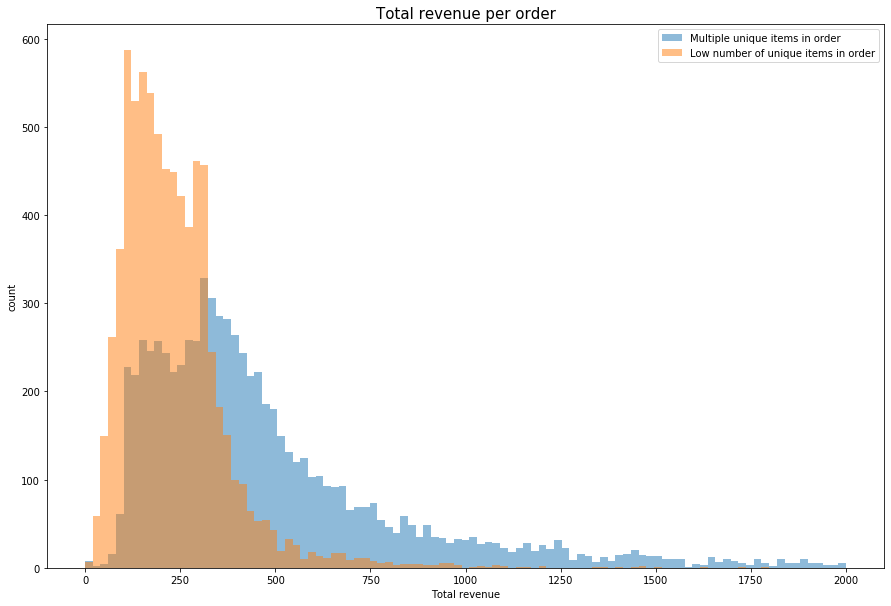

```python
bins = np.linspace(0, 2000, 100)
plt.figure(figsize=(15,10))
plt.hist(rev_high_u, bins=bins, alpha=0.5, label='Multiple unique items in order')
plt.hist(rev_low_u, bins=bins, alpha=0.5, label='Low number of unique items in order')
plt.legend(loc='upper right')
plt.title('Total revenue per order', fontsize=15)
plt.xlabel('Total revenue')
plt.ylabel('count')
plt.show()
```

#### From the graph it seems multiple-item orders bring more revenue in general, but let's check it with a test.

Jump to test

#### Les't see how many orders do our customers make:

```python
n_ord = data.query('uid != 0').groupby('uid')['order_id'].nunique().sort_values().reset_index()
n_ord['order_id'].value_counts().head(20)
```

```
1     1481
2      810
3      493
4      382
5      222
6      165
7      125
8      103
9       61
10      57
11      51
13      36
12      30
16      20
17      19
14      17
15      16
18      12
19      12
21       9
Name: order_id, dtype: int64
```

```python
n_ord['order_id'].describe()
```

```
count    4194.000000
mean        4.044111
std         7.091088
min         1.000000
25%         1.000000
50%         2.000000
75%         4.000000
max       199.000000
Name: order_id, dtype: float64
```

#### We'll consider those who make more than 5 orders as multi-order users and check if they bring us more revenue than low orders customers:

```python
low_ord_l = n_ord.query('order_id <= 5')['uid'].to_list()
multi_ord_l = n_ord.query('order_id > 5')['uid'].to_list()
low_ord_rev = data.query('uid == @low_ord_l').groupby('order_id')['revenue'].mean()
multi_ord_rev = data.query('uid == @multi_ord_l').groupby('order_id')['revenue'].mean()
```

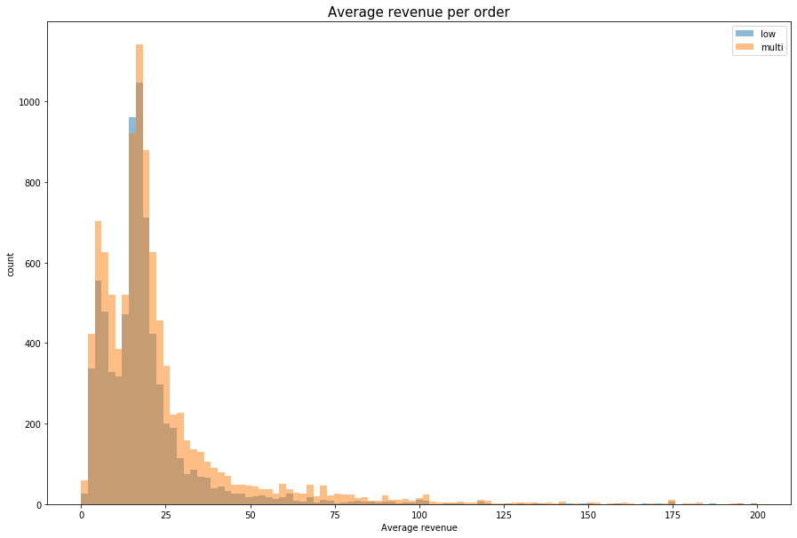

```python
bins = np.linspace(0, 200, 100)
plt.figure(figsize=(15,10))
plt.hist(low_ord_rev, bins=bins, alpha=0.5, label='low')
plt.hist(multi_ord_rev, bins=bins, alpha=0.5, label='multi')
plt.legend(loc='upper right')
plt.title('Average revenue per order', fontsize=15)
plt.xlabel('Average revenue')
plt.ylabel('count')
plt.show()
```

#### We'll check the hypotheses that there's no difference in revenue between them.

Jump to test

#### Let's compare top 10 items:

```python
ret_items = data.query('order_id == @ret_orders and name != "POSTAGE"').groupby('name')['revenue'].sum().sort_values().tail(10)
ind_items = data.query('order_id != @ret_orders and name != "POSTAGE"').groupby('name')['revenue'].sum().sort_values().tail(10)
```

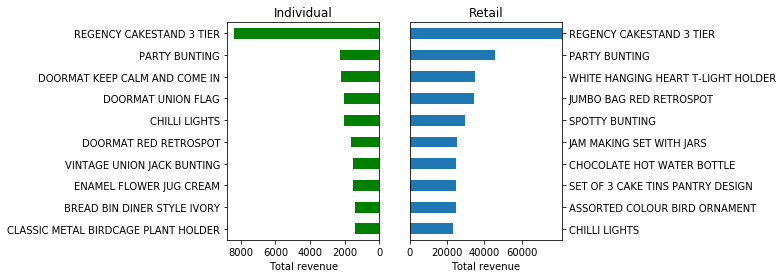

```python
fig, (ax, ax2) = plt.subplots(ncols=2)

ax.invert_xaxis()
ax2.yaxis.tick_right()

ind_items.plot(kind='barh',  legend=False, ax=ax, color='green', title='Individual')
plt.xlim(0, pd.concat([ind_items, ret_items]).max())
ret_items.plot(kind='barh',ax=ax2, title='Retail')
ax.set_xlabel('Total revenue')
ax2.set_xlabel('Total revenue')
plt.sca(ax)
plt.xticks(np.arange(0, 10000, 2000))
plt.sca(ax2)
plt.xticks(np.arange(0, 80000, 20000))
ax.set_ylabel('')
ax2.set_ylabel('')
plt.show()
```

#### There are some differencies in top 10 most popular items between individual and retail customers.

#### Let's find the most popular item pairs in orders:

```python
data.info()
```

```
<class 'pandas.core.frame.DataFrame'>
Int64Index: 487379 entries, 5221 to 541903
Data columns (total 12 columns):
 #   Column       Non-Null Count   Dtype
---  ------       --------------   -----
 0   order_id     487379 non-null  object
 1   item_id      487379 non-null  category
 2   name         487379 non-null  object
 3   quantity     487379 non-null  int64
 4   date         487379 non-null  datetime64[ns]
 5   unitprice    487379 non-null  float64
 6   uid          487379 non-null  int32
 7   day          487379 non-null  object
 8   revenue      487379 non-null  float64
 9   week         487379 non-null  int64
 10  month        487379 non-null  int64
 11  order_month  487379 non-null  datetime64[ns]
dtypes: category(1), datetime64[ns](2), float64(2), int32(1), int64(3), object(3)
memory usage: 43.9+ MB
```

```python
dgrouped = data.query('uid == @ret_users').sort_values(by=['order_id', 'item_id'])
dgrouped = dgrouped.groupby(['order_id'])['item_id'].apply(list)
dgrouped = dgrouped.to_frame()
```

```python
data_list = np.array_split(dgrouped, 20)
```

```python
final = []
for d in data_list:
    comb = lambda x: list(it.combinations(x, 2))
    L = d['item_id'].map(comb).tolist()
    pairs = pd.DataFrame(L).stack().value_counts(sort=True)#.idxmax(#)
    final.append(pairs)
```

```python
df = pd.DataFrame()
for f in final:
    f = f.to_frame()
    df = df.add(f, fill_value=0)
```

```python
pairs_df = df.sort_values(by=0).reset_index()
pairs_df.columns = ['item', 'n_pairs']
pairs_20 = pairs_df.tail(20).reset_index()
pairs = pd.DataFrame(pairs_20['item'].tolist())

pairs['n_pairs'] = pairs_20['n_pairs']
p0 = pairs[0].to_list()
p1 = pairs[1].to_list()
pairs.columns = ['item_0', 'item_1', 'n_pairs']
```

```python
pairs = pairs.merge(data.query('item_id == @p0')[['item_id', 'name']].drop_duplicates(), left_on=['item_0'], right_on='item_id').drop('item_id', axis=1)
pairs.rename(columns={'name' : 'name_0'}, inplace=True)
pairs = pairs.merge(data.query('item_id == @p1')[['item_id', 'name']].drop_duplicates(), left_on=['item_1'], right_on='item_id').drop('item_id', axis=1)
pairs.rename(columns={'name': 'name_1'}, inplace=True)
pairs = pairs.drop(['item_0', 'item_1'], axis=1).sort_values(by='n_pairs')
```

```python
pairs
```

|  | n_pairs | name_0 | name_1 |
| --- | --- | --- | --- |
| 0 | 420.0 | LUNCH BAG BLACK SKULL. | LUNCH BAG SPACEBOY DESIGN |
| 11 | 424.0 | PINK REGENCY TEACUP AND SAUCER | ROSES REGENCY TEACUP AND SAUCER |
| 13 | 425.0 | WOODEN PICTURE FRAME WHITE FINISH | WOODEN FRAME ANTIQUE WHITE |
| 2 | 426.0 | LUNCH BAG BLACK SKULL. | LUNCH BAG CARS BLUE |
| 14 | 427.0 | LUNCH BAG RED RETROSPOT | LUNCH BAG WOODLAND |
| 6 | 429.0 | LUNCH BAG CARS BLUE | LUNCH BAG PINK POLKADOT |
| 10 | 446.0 | LUNCH BAG SPACEBOY DESIGN | LUNCH BAG SUKI DESIGN |
| 9 | 446.0 | LUNCH BAG CARS BLUE | LUNCH BAG SUKI DESIGN |
| 16 | 447.0 | GREEN REGENCY TEACUP AND SAUCER | PINK REGENCY TEACUP AND SAUCER |
| 17 | 448.0 | GARDENERS KNEELING PAD CUP OF TEA | GARDENERS KNEELING PAD KEEP CALM |
| 3 | 449.0 | LUNCH BAG RED RETROSPOT | LUNCH BAG CARS BLUE |
| 1 | 456.0 | LUNCH BAG RED RETROSPOT | LUNCH BAG SPACEBOY DESIGN |
| 4 | 470.0 | LUNCH BAG BLACK SKULL. | LUNCH BAG PINK POLKADOT |
| 7 | 477.0 | LUNCH BAG BLACK SKULL. | LUNCH BAG SUKI DESIGN |
| 18 | 499.0 | JUMBO BAG PINK POLKADOT | JUMBO BAG RED RETROSPOT |
| 8 | 511.0 | LUNCH BAG RED RETROSPOT | LUNCH BAG SUKI DESIGN |
| 5 | 514.0 | LUNCH BAG RED RETROSPOT | LUNCH BAG PINK POLKADOT |
| 15 | 523.0 | LUNCH BAG RED RETROSPOT | LUNCH BAG BLACK SKULL. |
| 19 | 526.0 | ALARM CLOCK BAKELIKE GREEN | ALARM CLOCK BAKELIKE RED |
| 12 | 527.0 | GREEN REGENCY TEACUP AND SAUCER | ROSES REGENCY TEACUP AND SAUCER |

#### Since there's a lot of retailers, the most popular pairs are similar items.

#### Let's check how the revenue from our top 50 users looks:

```python
top_50_c = data.query('uid != 0').groupby('uid').agg({'revenue' : 'sum'}).sort_values(by='revenue', ascending=False).head(50)
```

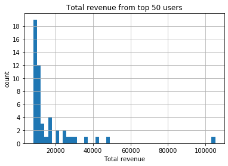

```python
top_50_c.hist(bins=50)
plt.yticks(np.arange(0, 20, 2.0))
plt.title('Total revenue from top 50 users')
plt.xlabel('Total revenue')
plt.ylabel('count')
```

```python
top_50_c['revenue'].describe()
```

```
count        50.000000
mean      16668.087000
std       15717.953406
min        8397.080000
25%        9591.840000
50%       10582.885000
75%       16545.477500
max      105144.120000
Name: revenue, dtype: float64
```

#### The revenue from our top 50 customers varies between 8000 (most of them) to 100000 (absolute winner!)

```python
top_50_cid = top_50_c.index.to_list()
top_50_ord = data.query('uid == @top_50_cid').groupby('order_id').agg({'item_id' : 'unique',
                                                                       'revenue' : 'sum'}).sort_values(by='revenue')
```

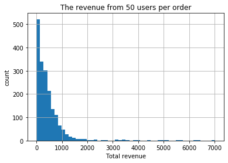

```python
top_50_ord['revenue'].hist(bins=50)
plt.title('The revenue from 50 users per order')
plt.xlabel('Total revenue')
plt.ylabel('count')
```

```python
top_50_ord['revenue'].describe()
```

```
count    1851.000000
mean      450.245462
std       593.893134
min         0.000000
25%       119.510000
50%       302.240000
75%       571.695000
max      7016.220000
Name: revenue, dtype: float64
```

#### This is how revenue from these customers is distributed per order. Half of the orders have the revenue below 300, but it reaches up to 7000 per order! Let's compare to average paycheck:

```python
data.groupby('order_id').agg({'revenue' : 'sum'}).mean()
```

```
revenue    328.717649
dtype: float64
```

```python
t = top_50_c.index.to_list()
t_items = data.query('uid == @t').groupby('name')['quantity'].sum().sort_values().tail(10).to_frame()
```

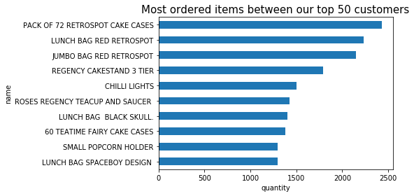

```python
t_items.plot(kind='barh', legend=False)
plt.title('Most ordered items between our top 50 customers', fontsize=15)
plt.xlabel('quantity')
```

#### The most ordered items by our top customers reach 1500-2500 total items.

#### Let's investigate the daily and monthly revenue:

```python
data.groupby('day')['revenue'].sum().mean()#.plot(kind='line')
```

```
20487.897042904337
```

```python
data.groupby('month')['revenue'].sum()
```

```
month
1     420330.330
2     327340.030
3     417485.100
4     334218.271
5     492009.570
6     399109.220
7     446282.751
8     442275.850
9     595239.492
10    736204.840
11    949235.280
12    648102.070
Name: revenue, dtype: float64
```

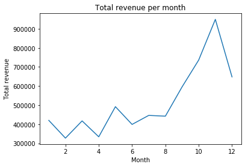

```python
data.groupby('month')['revenue'].sum().plot(kind='line')
plt.title('Total revenue per month')
plt.xlabel('Month')
plt.ylabel('Total revenue')
```

#### The average daily revenue is 20000. The total revenue by month is repesentet on the graph - predictably peaks in October and November.

#### ARPPU

```python
arpu = data.groupby(['month']).agg({'revenue' : 'sum', 'uid' : 'nunique'})#.mean()
arpu['arpu'] = arpu['revenue']/arpu['uid']
```

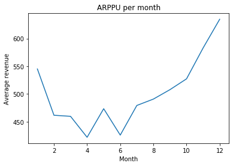

```python
arpu['arpu'].plot(kind='line')
plt.title('ARPPU per month')
plt.xlabel('Month')
plt.ylabel('Average revenue')
```

#### Average revenue per paying user varies between 400-650.

#### Retention

```python
visits_min = data.groupby('uid')['day'].min()
visits_min.name = 'first_visit'
data = data.merge(visits_min, on='uid',  how='left')
ret = data.query('uid != 0').groupby(['order_id', 'uid', 'first_visit'], as_index=False).agg({'day' :'min'}).sort_values(by=['uid', 'day'])

ret['first_visit'] = pd.to_datetime(ret['first_visit'], format='%Y-%m-%d')
ret['day'] = pd.to_datetime(ret['day'], format='%Y-%m-%d')
ret['seniority'] = round(((ret['day'] - ret['first_visit']).dt.days) / 30, 0)#.astype('timedelta64[M]')#.astype('int')
ret['cohort_month'] = ret['first_visit'].astype('datetime64[M]')
```

```python
cohort_data = ret.groupby(['cohort_month', 'seniority'])['uid'].size().reset_index()
```

```python
cohort_counts = cohort_data.pivot_table(index='cohort_month', columns='seniority', values='uid')

base = cohort_counts[0]
retention = cohort_counts.divide(base, axis=0).round(2)
```

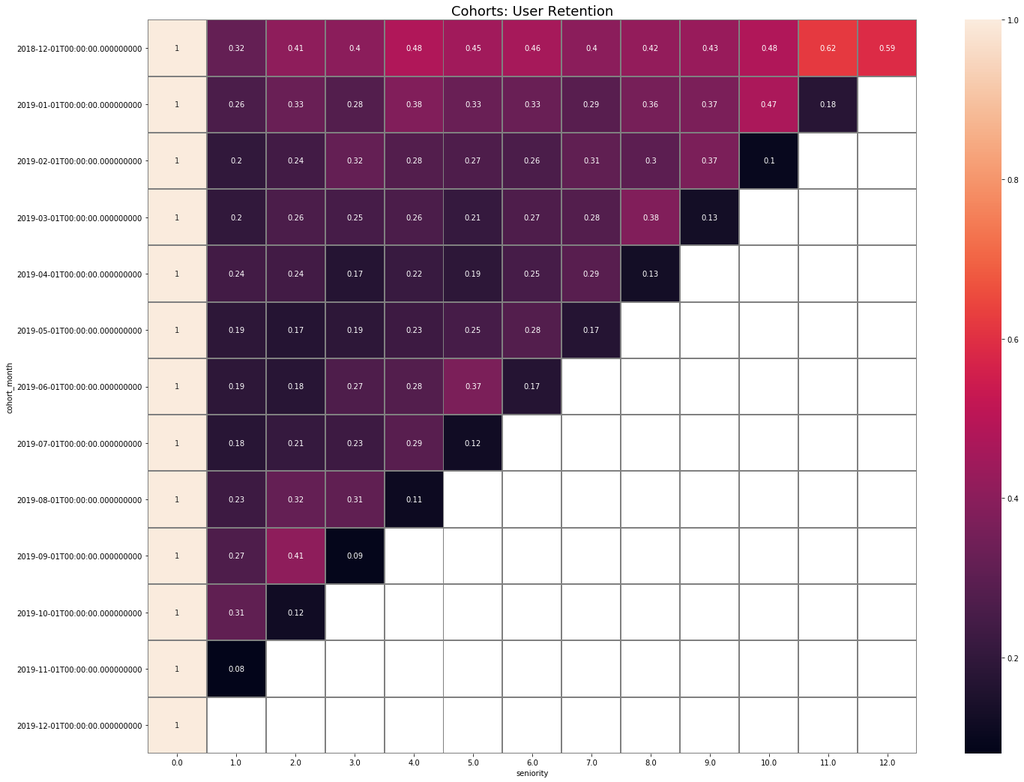

```python
plt.figure(figsize=(23, 18))
sns.heatmap(retention, annot=True, linewidths=1, linecolor='gray')
plt.title('Cohorts: User Retention', fontsize=18)
```

#### Cohorts analysis - LTV:

```python
data['cohort'] = data['first_visit'].astype('datetime64[M]')
cohort_sizes = data.groupby('cohort')['uid'].nunique().reset_index()
cohort_sizes.columns = ['first_order_month', 'n_users']
```

```python
data['uid'].nunique()
```

```
4195
```

```python
cohort_sizes.columns = ['first_order_month', 'n_users']
```

```python
cohorts = data.query('uid != "0"').groupby(['first_visit','order_month']).agg({'revenue': 'sum'}).reset_index()
cohorts.columns = ['first_order_month', 'order_month', 'revenue']
cohorts['first_order_month'] = cohorts['first_order_month'].astype('datetime64[M]')
cohorts['order_month'] = cohorts['order_month'].astype('datetime64[M]')
```

```python
margin_rate = 0.4 #Average rate on market, was not given in data or description

report = pd.merge(cohort_sizes, cohorts, on='first_order_month')
report['gp'] = report['revenue'] * margin_rate
report['age'] = (report['order_month'] - report['first_order_month']) / np.timedelta64(1, 'M')#.astype(int)
report['age'] = report['age'].round().astype('int')
report.head()
```

|  | first_order_month | n_users | order_month | revenue | gp | age |
| --- | --- | --- | --- | --- | --- | --- |
| 0 | 2018-12-01 | 736 | 2018-12-01 | 25184.71 | 10073.884 | 0 |
| 1 | 2018-12-01 | 736 | 2019-01-01 | 15780.32 | 6312.128 | 1 |
| 2 | 2018-12-01 | 736 | 2019-02-01 | 5765.02 | 2306.008 | 2 |
| 3 | 2018-12-01 | 736 | 2019-03-01 | 14979.00 | 5991.600 | 3 |
| 4 | 2018-12-01 | 736 | 2019-04-01 | 7557.99 | 3023.196 | 4 |

```python
report['ltv'] = report['gp'] / report['n_users']

output = report.pivot_table(
    index='first_order_month',
    columns='age',
    values='ltv',
    aggfunc='mean')#.round()


output = output.cumsum(axis=1)
output.fillna('')
```

| age first_order_month | 0 | 1 | 2 | 3 | 4 | 5 | 6 | 7 | 8 | 9 | 10 | 11 | 12 |
| --- | --- | --- | --- | --- | --- | --- | --- | --- | --- | --- | --- | --- | --- |
| 2018-12-01 | 8.887191 | 13.4179 | 16.4957 | 20.5862 | 23.9159 | 28.8737 | 32.6648 | 36.6142 | 41.1971 | 46.4072 | 51.906 | 59.7332 | 61.9914 |
| 2019-01-01 | 5.511858 | 6.63855 | 8.07628 | 9.22775 | 11.5396 | 13.2594 | 14.9804 | 16.6312 | 18.7597 | 21.3046 | 24.2116 | 24.816 |  |
| 2019-02-01 | 6.139797 | 7.07921 | 8.17826 | 10.0353 | 11.5834 | 12.8484 | 14.5511 | 16.8785 | 18.8452 | 21.2163 | 21.6319 |  |  |
| 2019-03-01 | 5.300664 | 6.03523 | 7.73851 | 8.91145 | 10.1661 | 11.4397 | 12.9904 | 14.7863 | 16.711 | 17.0807 |  |  |  |
| 2019-04-01 | 6.358136 | 7.68969 | 9.04963 | 10.3775 | 11.6652 | 13.1642 | 15.0827 | 17.1587 | 17.6552 |  |  |  |  |
| 2019-05-01 | 4.881223 | 5.72001 | 6.61832 | 7.47627 | 9.3023 | 10.8858 | 12.7965 | 13.4557 |  |  |  |  |  |
| 2019-06-01 | 4.792774 | 5.815 | 6.65874 | 8.33252 | 10.0987 | 12.2552 | 12.8905 |  |  |  |  |  |  |
| 2019-07-01 | 5.259744 | 6.31868 | 7.90426 | 9.34902 | 11.0383 | 11.7613 |  |  |  |  |  |  |  |
| 2019-08-01 | 5.319563 | 7.52955 | 10.9726 | 14.9086 | 17.0673 |  |  |  |  |  |  |  |  |
| 2019-09-01 | 6.306533 | 7.8385 | 9.77562 | 10.5748 |  |  |  |  |  |  |  |  |  |
| 2019-10-01 | 5.444184 | 6.86795 | 7.31296 |  |  |  |  |  |  |  |  |  |  |
| 2019-11-01 | 5.064706 | 5.51586 |  |  |  |  |  |  |  |  |  |  |  |
| 2019-12-01 | 14.987978 |  |  |  |  |  |  |  |  |  |  |  |  |

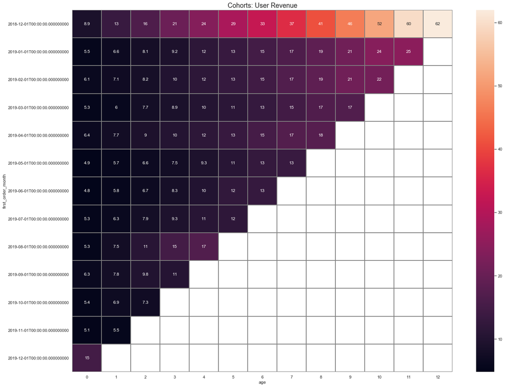

```python
sns.set(style='white')
plt.figure(figsize=(23, 18))
plt.title('Cohorts: User Revenue', fontsize=18)
sns.heatmap(output, annot=True, linewidths=1, linecolor='gray')
```

#### The Dec, 2018 cohort is the most profitable. Maybe because they hit two end-of-the-year holiday seasons, when sales are high. The Dec, 2019 cohort is a record holder for the first month profit. Also the August cohort speeded up towards the end of the year, hitting 17 cumulative revenue in 5 month - more everyone, except for Dec, 2018 cohort.

#### Top 10 selling products analysis

```python
top_quan = data['revenue'].max()
top_quan
```

```
508.5
```

```python
data.query('revenue == @top_quan')
```

|  | order_id | item_id | name | quantity | date | unitprice | uid | day | revenue | week | month | order_month | first_visit | cohort |
| --- | --- | --- | --- | --- | --- | --- | --- | --- | --- | --- | --- | --- | --- | --- |
| 254607 | 561901 | 22797 | CHEST OF DRAWERS GINGHAM HEART | 30 | 2019-07-29 15:42:00 | 16.95 | 14156 | 2019-07-29 | 508.5 | 31 | 7 | 2019-07-01 | 2019-01-12 | 2019-01-01 |

```python
top_revenue = data.groupby('item_id').agg({'revenue' : 'sum', 'quantity' : 'sum'}).sort_values(by='revenue', ascending=False).head(10)
top_revenue = top_revenue.index.to_list()
```

```
'c' argument looks like a single numeric RGB or RGBA sequence, which should be avoided as value-mapping will have precedence in case its length matches with 'x' & 'y'.  Please use a 2-D array with a single row if you really want to specify the same RGB or RGBA value for all points.
```

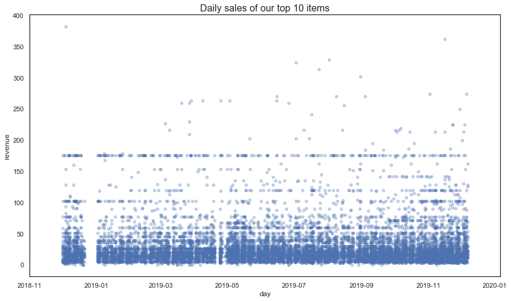

```python
data.query('item_id == @top_revenue')[['day','revenue']].plot(x='day', y='revenue', kind='scatter', figsize=(14,8), alpha=0.3)
plt.title('Daily sales of our top 10 items', fontsize=16)
```

#### Our top 10 most selling products generate up to 50 revenue per day, but sometimes it is over 150.

```python
sns.set_theme(style="darkgrid")
```

```python
top_revenue = data.query('name != "mailout" and name != "POSTAGE"'
                        ).groupby('item_id').agg({'revenue' : 'sum'}).sort_values(by='revenue', ascending=False).head(10)
top_revenue_list = top_revenue.index.to_list()
top_revenue_df = data.query('item_id == @top_revenue_list').groupby(['name', 'month'], as_index=False)['revenue'].sum()
top_revenue_names = top_revenue_df.groupby('name').agg({'revenue' : 'sum'}).sort_values(by='revenue',
                                                                                           ascending=False).index.to_list()
```

```python
top_r_size = pd.DataFrame(top_revenue_names).reset_index()
top_revenue_df = top_revenue_df.merge(top_r_size, left_on='name', right_on=0)
top_revenue_df = top_revenue_df.sort_values(by='index', ascending=True)
```

```
 <a list of 13 Text xticklabel objects>)
```

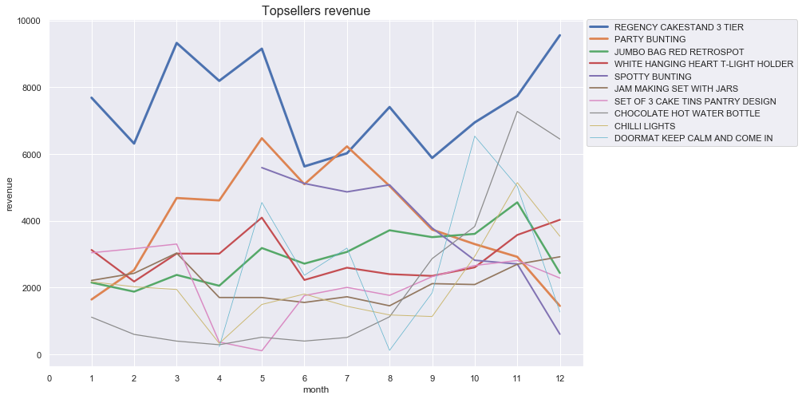

```python
plt.figure(figsize=(12,8))
sns.lineplot(x='month', y='revenue', data=top_revenue_df, hue='name', hue_order=top_revenue_names, ci=None, size='name')
plt.legend(bbox_to_anchor=(1.40, 1), borderaxespad=0)
plt.title('Topsellers revenue', fontsize=16)
plt.xticks(np.arange(0, 13, 1.0))
```

```python
pair_temp = pd.DataFrame(pairs_df['item'].tolist())
pair_temp = pair_temp.join(pairs_df)
pair_temp.columns = ['item_0', 'item_1', 'pairs_item', 'n_pairs']
top_revenue_pairs = pd.DataFrame()
for p in top_revenue_list:
    top_revenue_pairs = top_revenue_pairs.append(pair_temp.query('item_0 == @p').tail(1))
```

```python
top_revenue_pairs['name_0'] = top_revenue_pairs.apply(lambda x: data[data['item_id'] == x['item_0']]['name'].iloc[0], axis=1)
top_revenue_pairs['name_1'] = top_revenue_pairs.apply(lambda x: data[data['item_id'] == x['item_1']]['name'].iloc[0], axis=1)
top_revenue_pairs = top_revenue_pairs.drop(['item_0', 'item_1', 'pairs_item'], axis=1)
```

```python
top_revenue_pairs
```

|  | n_pairs | name_0 | name_1 |
| --- | --- | --- | --- |
| 2109245 | 388.0 | REGENCY CAKESTAND 3 TIER | ROSES REGENCY TEACUP AND SAUCER |
| 2109132 | 232.0 | PARTY BUNTING | WHITE HANGING HEART T-LIGHT HOLDER |
| 2109232 | 341.0 | JUMBO BAG RED RETROSPOT | JUMBO BAG STRAWBERRY |
| 2108669 | 134.0 | WHITE HANGING HEART T-LIGHT HOLDER | HAND OVER THE CHOCOLATE SIGN |
| 2109242 | 377.0 | SPOTTY BUNTING | PARTY BUNTING |
| 2109201 | 276.0 | JAM MAKING SET WITH JARS | JAM MAKING SET PRINTED |
| 2109215 | 297.0 | SET OF 3 CAKE TINS PANTRY DESIGN | SET OF 6 SPICE TINS PANTRY DESIGN |
| 2109210 | 288.0 | CHOCOLATE HOT WATER BOTTLE | HOT WATER BOTTLE I AM SO POORLY |
| 2105706 | 65.0 | CHILLI LIGHTS | WHITE HANGING HEART T-LIGHT HOLDER |
| 2108536 | 124.0 | DOORMAT KEEP CALM AND COME IN | GARDENERS KNEELING PAD KEEP CALM |

#### Our top sellers are usually bought with these items. They are either similar items or another top seller.

#### Here's the top 10 selling products revenue by months. Most of them earn us 2000-4000 per month.

```python
top_quantity = data.query('name != "mailout" and name != "POSTAGE"'
                         ).groupby('item_id').agg({'quantity' : 'sum'}).sort_values(by='quantity', ascending=False).head(10)
top_quantity_list = top_quantity.index.to_list()
top_quantity_df = data.query('item_id == @top_quantity_list').groupby(['name', 'month'], as_index=False)['quantity'].sum()
top_quantity_names = top_quantity_df.groupby('name').agg({'quantity' : 'sum'}).sort_values(by='quantity',
                                                                                           ascending=False).index.to_list()
```

```python
top_q_size = pd.DataFrame(top_quantity_names).reset_index()
top_quantity_df = top_quantity_df.merge(top_q_size, left_on='name', right_on=0).sort_values(by='index', ascending=True)
```

```
 <a list of 13 Text xticklabel objects>)
```

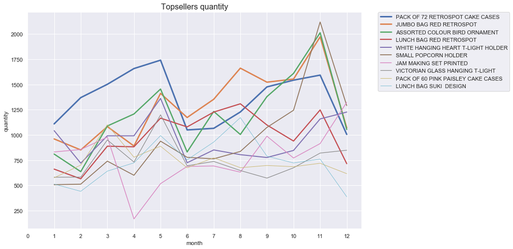

```python
plt.figure(figsize=(12,8))
sns.lineplot(x='month', y='quantity', data=top_quantity_df, hue='name', ci=None, hue_order=top_quantity_names, size='name')
plt.legend(bbox_to_anchor=(1.05, 1), borderaxespad=0)
plt.title('Topsellers quantity', fontsize=16)
plt.xticks(np.arange(0, 13, 1.0))
```

#### The top 10 most ordered items. The quantities often over 1000 per month.

```python
top100_revenue = data.query('name != "mailout" and name != "POSTAGE"').groupby('item_id').agg({'revenue' : 'sum'}).sort_values(by='revenue',
                                                                                                     ascending=False).head(100).index.to_list()
```

```python
season = data.query('item_id == @top100_revenue').groupby(['name', 'month']).agg({'revenue' : 'sum'}).reset_index()
season['diff'] = season['revenue'].diff()
n_month = season.groupby('name').agg({'month' : 'nunique'}).reset_index()
season = season.merge(n_month, on='name')
diff_head = season.query('month_x != [1, 12] and month_y == 12').groupby('name', as_index=False)['diff'].max().sort_values(by='diff', ascending=False).head(10)['name'].to_list()
diff_tail = season.query('month_x != [1, 12] and month_y == 12').groupby('name', as_index=False)['diff'].min().sort_values(by='diff').head(10)['name'].to_list()
```

```python
season.query('month_x != [1, 12] and month_y == 12').groupby('name', as_index=False)['diff'].max()
```

|  | name | diff |
| --- | --- | --- |
| 0 | 6 RIBBONS RUSTIC CHARM | 384.26 |
| 1 | ALARM CLOCK BAKELIKE GREEN | 1951.25 |
| 2 | ALARM CLOCK BAKELIKE PINK | 801.79 |
| 3 | ALARM CLOCK BAKELIKE RED | 1582.71 |
| 4 | ANTIQUE SILVER TEA GLASS ETCHED | 889.21 |
| ... | ... | ... |
| 75 | WHITE SKULL HOT WATER BOTTLE | 1126.85 |
| 76 | WOOD BLACK BOARD ANT WHITE FINISH | 1012.78 |
| 77 | WOOD S/3 CABINET ANT WHITE FINISH | 950.53 |
| 78 | WOODEN FRAME ANTIQUE WHITE | 1258.18 |
| 79 | WOODEN PICTURE FRAME WHITE FINISH | 640.32 |

80 rows × 2 columns

```python
diff_head_size = pd.DataFrame(diff_head).reset_index()
diff_tail_size = pd.DataFrame(diff_tail).reset_index()
diff_head_df = data.query('name == @diff_head').groupby(['name', 'month'], as_index=False)['revenue'].sum()
diff_tail_df = data.query('name == @diff_tail').groupby(['name', 'month'], as_index=False)['revenue'].sum()
diff_tail_df = diff_tail_df.merge(diff_tail_size, left_on='name', right_on=0).sort_values(by='index', ascending=True)
diff_head_df = diff_head_df.merge(diff_head_size, left_on='name', right_on=0).sort_values(by='index', ascending=True)
```

#### Season-dependance analysis

```
 <a list of 13 Text xticklabel objects>)
```

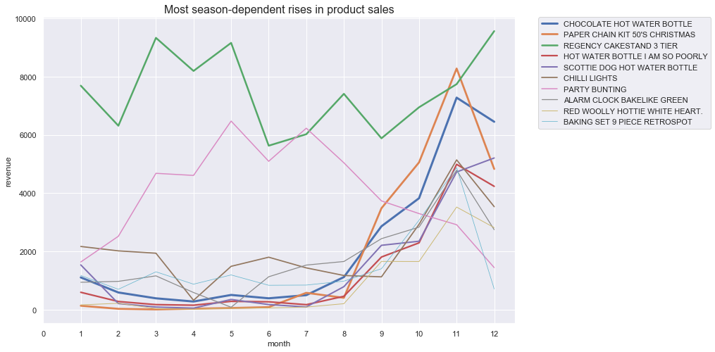

```python
plt.figure(figsize=(12,8))
sns.lineplot(x='month', y='revenue', data=diff_head_df, hue='name', ci=None, size='name')
plt.legend(bbox_to_anchor=(1.05, 1), borderaxespad=0)
plt.title('Most season-dependent rises in product sales', fontsize=16)
plt.xticks(np.arange(0, 13, 1.0))
```

#### Most season-related sale rises occur towards the winter holidays.

```
 <a list of 13 Text xticklabel objects>)
```

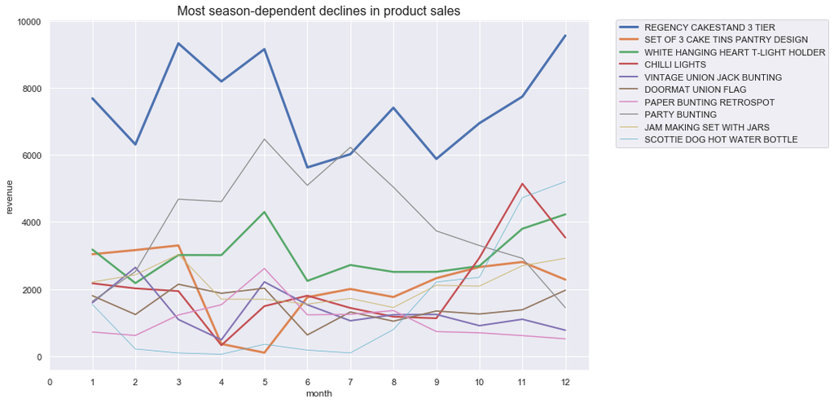

```python
plt.figure(figsize=(12,8))
sns.lineplot(x='month', y='revenue', data=diff_tail_df, hue='name', ci=None, size='name')
plt.legend(bbox_to_anchor=(1.05, 1), borderaxespad=0.)
plt.title('Most season-dependent declines in product sales', fontsize=16)
plt.xticks(np.arange(0, 13, 1.0))
```

#### Most of the season-related sale declines before summer.

#### Let's dive into names/keywords analysis. First we search for packs/sets (if digit is more than 10 and not g/lb/oz after digit it is probably a pack:)

```python
packs = data[(data['name'].str.contains(pat="(\d{2,})(?=[ ])",
                                regex=True))].groupby('name', as_index=False).agg({'quantity' : 'median',
                                                                                   'revenue' : 'sum'}).sort_values(by='quantity').tail(50)
```

```python
packs['q'] = packs.apply(lambda x: int(re.search("(\d{2,})(?=[ ])", x['name']).group(1)), axis=1)
packs['quantity_needed'] = packs['quantity'] * packs ['q']
packs = packs.sort_values(by='quantity_needed').tail(20)
```

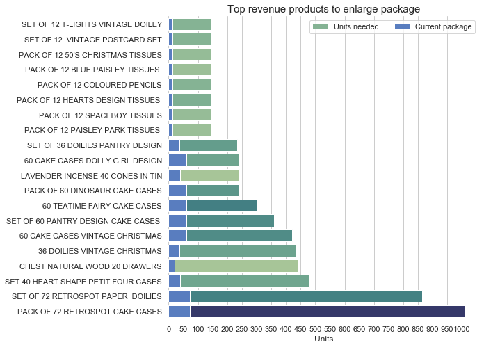

```python
sns.set_theme(style="whitegrid")

# Initialize the matplotlib figure
f, ax = plt.subplots(figsize=(8, 8))

# Load the example car crash dataset
crashes = sns.load_dataset("car_crashes").sort_values("total", ascending=False)
cm = sns.color_palette("rocket", as_cmap=True)
# Plot the total crashes
sns.set_color_codes("pastel")
sns.barplot(x="quantity_needed", y="name", data=packs,
            label="Units needed", color="b", palette=mpl.cm.ScalarMappable(cmap='crest').to_rgba(packs['revenue']))

# Plot the crashes where alcohol was involved
sns.set_color_codes("muted")
sns.barplot(x="q", y="name", data=packs,
            label="Current package", color="b")

# Add a legend and informative axis label
ax.legend(ncol=2, loc="upper right", frameon=True)
ax.set(ylabel="",
       xlabel="Units")
ax.set_title('Top revenue products to enlarge package', fontsize=15)
plt.xticks(np.arange(0, max(packs['quantity_needed'])+1, 50))
sns.despine(left=True, bottom=True)
```

#### As we see, some packages might be bigger for our customers' convinience. The green color intensity represents our total revenue from an item.

```python
grams = data[(data['name'].str.contains(pat="(\d)(?=g)",
                                regex=True))].groupby('name', as_index=False).agg({'quantity' : 'median',
                                                                                   'revenue' : 'sum'}).sort_values(by='quantity').tail(50)
```

```python
grams['g'] = grams.apply(lambda x: float(re.search(r"([-+]?\d*\.\d+|\d+)", x['name']).group(1)), axis=1)
grams['gram_needed'] = grams['quantity'] * grams ['g']
grams = grams.sort_values(by='gram_needed')
```

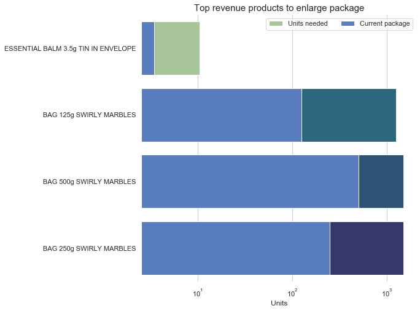

```python
f, ax = plt.subplots(figsize=(8, 8))

# Load the example car crash dataset
crashes = sns.load_dataset("car_crashes").sort_values("total", ascending=False)
cm = sns.color_palette("rocket", as_cmap=True)
# Plot the total crashes
sns.set_color_codes("pastel")
sns.barplot(x="gram_needed", y="name", data=grams,
            label="Units needed", color="b", palette=mpl.cm.ScalarMappable(cmap='crest').to_rgba(grams['revenue']))

# Plot the crashes where alcohol was involved
sns.set_color_codes("muted")
sns.barplot(x="g", y="name", data=grams,
            label="Current package", color="b")

# Add a legend and informative axis label
ax.legend(ncol=2, loc="upper right", frameon=True)
ax.set(ylabel="",
       xlabel="Units")
ax.set_title('Top revenue products to enlarge package', fontsize=15)
ax.set_xscale('log')
#plt.xticks(np.arange(0, max(grams['gram_needed'])+1, 50))
sns.despine(left=True, bottom=True)
```

#### There are some weighted products might better sold in bigger packages. Note that the scale is logarithmic. The green color intensity represents our total revenue from an item.

```python
data[(data['name'].str.contains(pat="(\d)(?=ml)",
                                regex=True))].groupby('name', as_index=False).agg({'quantity' : 'median',
                                                                                   'revenue' : 'sum'}).sort_values(by='quantity').tail(50)
```

|  | name | quantity | revenue |
| --- | --- | --- | --- |

```python
data[(data['name'].str.contains(pat="(\d)(?=kg)",
                                regex=True))].groupby('name', as_index=False).agg({'quantity' : 'median',
                                                                                   'revenue' : 'sum'}).sort_values(by='quantity').tail(50)
```

|  | name | quantity | revenue |
| --- | --- | --- | --- |

#### No items with other measure units.

```python
wood = (data[(data['name'].str.contains("WOOD"))
      & ~(data['name'].str.contains("WOODLAND"))].groupby('name')
        .agg({'quantity' : 'sum', 'revenue' : 'sum'}).sort_values(by='revenue', ascending=False))

metal = (data[(data['name'].str.contains("METAL"))]
                                        .groupby('name').agg({'quantity' : 'sum', 'revenue' : 'sum'})
                                        .sort_values(by='revenue', ascending=False))

ceram = (data[(data['name'].str.contains("CERAMIC"))]
                                             .groupby('name').agg({'quantity' : 'sum', 'revenue' : 'sum'})
                                             .sort_values(by='revenue', ascending=False))

paper = (data[(data['name'].str.contains("PAPER"))]
                                        .groupby('name').agg({'quantity' : 'sum', 'revenue' : 'sum'})
                                        .sort_values(by='revenue', ascending=False))

glass = (data[(data['name'].str.contains("GLASS"))]
                                        .groupby('name').agg({'quantity' : 'sum', 'revenue' : 'sum'})
                                        .sort_values(by='revenue', ascending=False))
materials = []
materials.append(wood)
materials.append(metal)
materials.append(ceram)
materials.append(paper)
materials.append(glass)
```

```
wood 502.8738254420142
metal 516.8895591850487
ceramic 635.6351491608023
paper 539.6297137739571
glass 523.1239410204099
```

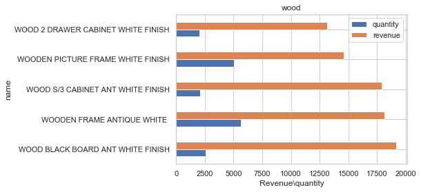

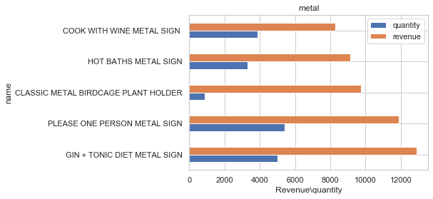

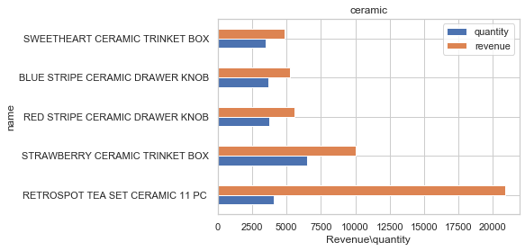

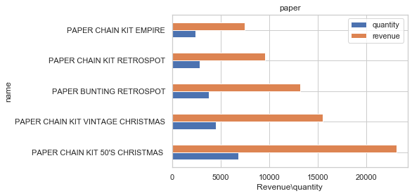

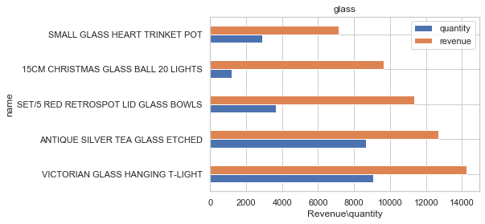

```python
mat = ['wood', 'metal', 'ceramic', 'paper', 'glass']
for m in range(0, len(materials)):
    materials[m].head().plot(kind='barh', title=mat[m])
    plt.xlabel('Revenue\quantity')
    materials[m].reset_index(inplace=True)
    m_name = materials[m]['name'].to_list()
    order = data.query('name == @m_name')['order_id'].to_list()
    print(mat[m], data.query('order_id == @order').groupby('order_id').revenue.sum().mean())
```

```python
words = pd.Series(re.sub(r'([^a-zA-Z0-9\s]| AND |\b\w{1,2}\b)', '', ' '.join(data['name'])).split()).value_counts().index
```

```python
words#.value_counts()
```

```
Index(['SET', 'BAG', 'RED', 'HEART', 'RETROSPOT', 'DESIGN', 'VINTAGE', 'PINK',
       'CHRISTMAS', 'BOX',
       ...
       'BAZAAR', 'Found', 'adjustment', 'CUTGLASS', 'Classic', 'DEMI', '16963',
       '17220', '16954', 'LILACRED'],
      dtype='object', length=2160)
```

```python
words_total = {}
for w in words:
    #print(w)
    words_total[w] = (data[(data['name'].str.contains(w))].groupby('name').agg({'revenue' : 'sum'})
      .sort_values(by='revenue', ascending=False))['revenue'].sum()
```

```python
words_total = pd.DataFrame.from_dict(words_total, orient='index', columns=['total_revenue']).sort_values(by='total_revenue', ascending=False)
```

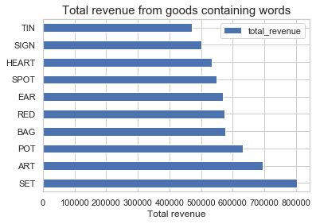

```python
words_total.head(10).plot(kind='barh')
plt.title('Total revenue from goods containing words', fontsize=15)
plt.xlabel('Total revenue')
```

#### There are some popular keywords that items include them have greater total revenue. `SET` is one of these words, we may conclude that there's a lot of item sets in product range. The word `HEART` is probably from a popular T-shirt/mug phrases "I Heart something", so items woth this phrase bring good revenue.

```python
words_avg = {}
for w in words:
    words_avg[w] = (data[(data['name'].str.contains(w))].groupby('name').agg({'revenue' : 'sum'})
      .sort_values(by='revenue', ascending=False))['revenue'].mean()
```

```python
words_avg = pd.DataFrame.from_dict(words_avg, orient='index', columns=['avg_revenue']).sort_values(by='avg_revenue', ascending=False)
```

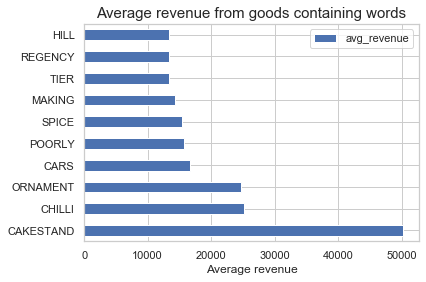

```python
words_avg.head(10).plot(kind='barh')
plt.title('Average revenue from goods containing words', fontsize=15)
plt.xlabel('Average revenue')
```

#### Here's the popular keywords for top average revenue items. Cakestand bring the best average revenue!

## 3. Hypotheses testing

```python
print('Independent users revenue mean:', ind_rev.revenue.mean(), 'Retail users revenue mean:', ret_rev.revenue.mean())
```

```
Independent users revenue mean: 67.78702564102572 Retail users revenue mean: 305.39102854384134
```

```python
alpha = .05

results = st.mannwhitneyu(rev_high_u.values, rev_low_u.values)

print('p-value: ', results.pvalue)

if (results.pvalue < alpha):
        print("We reject the null hypothesis")
else:
        print("We can't reject the null hypothesis")
```

```
p-value:  0.0
We reject the null hypothesis
```

#### Conclusion

We reject the null hypothesis - there's a difference between multiple-item orders and low-item orders. Multiple-item orders bring more revenue.

Jump back

### 2. More orders means more revenue?

```python
low_ord_rev = data.query('uid == @low_ord_l').groupby('order_id')['revenue'].mean()
multi_ord_rev = data.query('uid == @multi_ord_l').groupby('order_id')['revenue'].mean()
```

```python
print('Low-orders users revenue mean:', low_ord_rev.mean(), 'Multi-orders users revenue mean:', multi_ord_rev.mean())
```

```
Low-orders users revenue mean: 19.030717770603065 Multi-orders users revenue mean: 22.903155426262877
```

```python
low_ord_rev = low_ord_rev.reset_index()
multi_ord_rev = multi_ord_rev.reset_index()
```

```python
alpha = .05

results = st.mannwhitneyu(low_ord_rev['revenue'], multi_ord_rev['revenue'])

print('p-value: ', results.pvalue)

if (results.pvalue < alpha):
        print("We reject the null hypothesis")
else:
        print("We can't reject the null hypothesis")
```

```
p-value:  3.7226645412839735e-22
We reject the null hypothesis
```

#### Conclusion

We reject the null hypothesis that the average revenue for the users who make more than 5 orders is the same as for the users that make more than 5 orders - there's a difference between them. The latter users have greater average revenue.

Jump back

### Resources:

https://jet.style/blog/2018/basics-of-unit-economics-part-2-arpu-and-arppu-all-you-need-to-know-about-the-basic-metrics-of-unit-economics - ARPPU explanation  
https://www.putler.com/arppu/#:~:text=ARPPU%20is%20calculated%20as%20the,which%2030%20are%20paying%20users - ARPPU calculation  
https://towardsdatascience.com/how-to-calculate-customer-retention-rate-a-practical-approach-1c97709d495f - Retention calculation  
https://www.redalyc.org/jatsRepo/3989/398957817003/html/index.html Statistical test choosing